# exploring individual and L/R variation

Kushal K Dey, Joyce HSiao, Joe Paulson

August 27, 2015

We load the data and separate out the fossa and crease data.

```r
suppressMessages(suppressWarnings(library(metagenomeSeq)))
suppressMessages(suppressWarnings(library(maptpx)))
suppressMessages(suppressWarnings(library(tsne)))
suppressMessages(suppressWarnings(library(qtlcharts)))
library(qvalue)

#setwd('/Users/kushal/Documents/metagenomics/src')
load('../data/HMPvs35_nt100_MRexperiment.rdata')
hmp <- filterData(hmp,present=10);
#mat_temp <- t(MRcounts(hmp));
mat = t(MRcounts(hmp,norm=TRUE,log=TRUE));
mat_round <- round(mat);
metadata <- pData(hmp);
otu_data <- featureData(hmp)

hands_data <- mat_round[which(metadata$HMPbodysupersite=="Skin"),];
metadata <- metadata[which(metadata$HMPbodysupersite=="Skin"),];

fossa_crease_label <- sapply(1:dim(metadata)[1], function(x) strsplit(metadata$HMPbodysubsite[x],"_")[[1]][3]);

fossa_indices <- which(fossa_crease_label=='fossa');
crease_indices <- which(fossa_crease_label=='crease');

fossa_data <- hands_data[fossa_indices,];
crease_data <- hands_data[crease_indices,];

metadata_fossa <- metadata[fossa_indices,];
metadata_crease <- metadata[crease_indices,];
```

Number of fossa samples after filtering is 173 and number of crease samples after filtering is 627 which os quite higher.

## Fossa Structure analysis

Now we first define two grouping vectors, one for signifying the left hand or right hand sample and the other signifying the individual.

First with respect to the left hand right hand combination.

```r
left_right_label_fossa <- sapply(1:dim(metadata_fossa)[1], function(x) strsplit(metadata_fossa$HMPbodysubsite[x],"_")[[1]][1]);
```

Next with respect to the individual label.

```r
indiv_label_fossa <- sapply(1:dim(metadata_fossa)[1], function(x) strsplit(metadata_fossa$Description[x],"_")[[1]][8]);
```

```r
structure_fossa_metagenome <- function(counts_data,type_info,K)
{
  counts_data <- counts_data[which(!is.na(type_info)),];
  type_info <- type_info[which(!is.na(type_info))];
  Topic_Clus <- topics(counts_data,K,tol=0.0001);
  write.table(Topic_Clus$omega,paste0('../internal_data/hands_data/hands_topics_omega_',K,'.txt'));
  write.table(Topic_Clus$theta,paste0('../internal_data/hands_data/hands_topics_theta_',K,'.txt'));
  docweights <- as.matrix(read.table(paste0('../internal_data/hands_data/hands_topics_omega_',K,'.txt')));

  type_ordered <- type_info[order(type_info)];
  docweights_ordered <- docweights[order(type_info),];
  barplot(t(docweights_ordered),col=2:(K+1),axisnames=F,space=0,border=NA,main=paste("No. of clusters=",K),las=1,ylim=c(0,1),cex.axis=0.3,cex.main=1.4);
  labels = match(unique(type_ordered), type_ordered);
  abline(v=labels-1)

  labels_low=labels-1;
  labels_up=c(labels_low[2:length(labels_low)],dim(docweights_ordered)[1]);
  mid_point <- labels_low +0.5*(labels_up-labels_low);
  axis(1,at=mid_point, unique(type_ordered),las=2,cex.axis=0.3);
}
```

### Individual level variation

We first apply Structure model on the fossa data and sort the columns in the Structure plot as per the individual labels. The results for two same individuals are expected to be similar.

```r
sapply(2:4, function(k) structure_fossa_metagenome(fossa_data,indiv_label_fossa,k))
```

```
##
## Estimating on a 172 document collection.
## Fitting the 2 topic model.
## log posterior increase: 855.309, 567.2549, 110.4218, 47.1057, 30.0966, 19.2385, 17.5414, 5.8759, 2.7009, 0.5659, 0.2072, 0.1136, 0.0684, 0.0436, 0.032, 0.0341, 0.0508, 0.0515, 0.0628, 0.1032, 0.2396, 0.6849, 0.1864, 0.1336, 0.0817, 0.1193, 0.2269, 0.2013, 0.2785, 0.1775, 0.197, 0.2328, 0.9613, 0.…
```

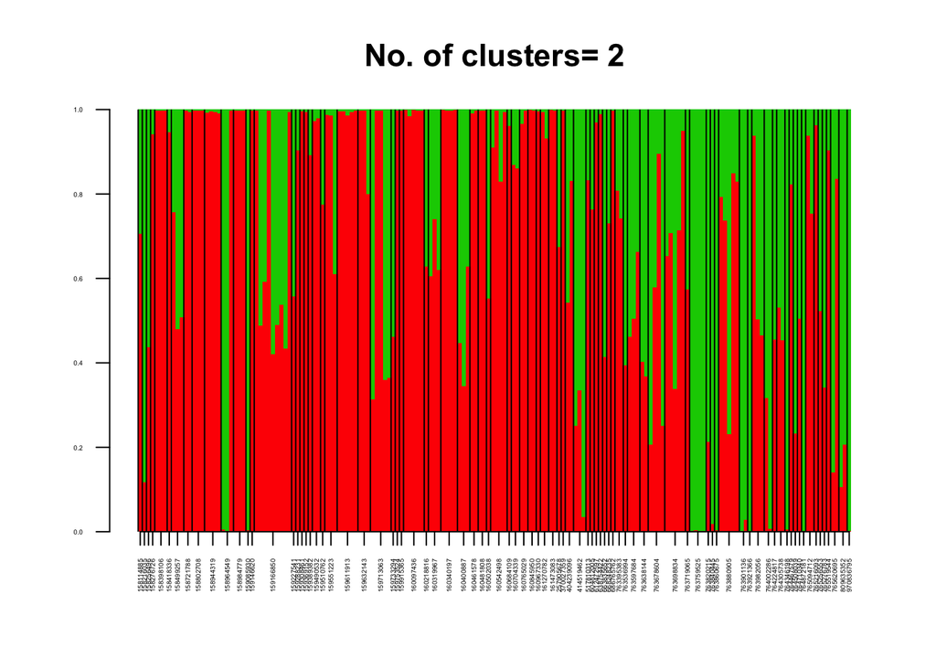

```
##
## Estimating on a 172 document collection.
## Fitting the 3 topic model.
## log posterior increase: 3147.379, 491.0719, 156.4045, 68.3286, 34.5558, 74.8943, 19.5515, 13.4133, 4.4823, 3.3843, 0.744, 0.4756, 0.3123, 0.1247, 0.0817, 0.0396, 0.0117, 0.0083, 0.0074, 0.005, 0.0034, done.
```

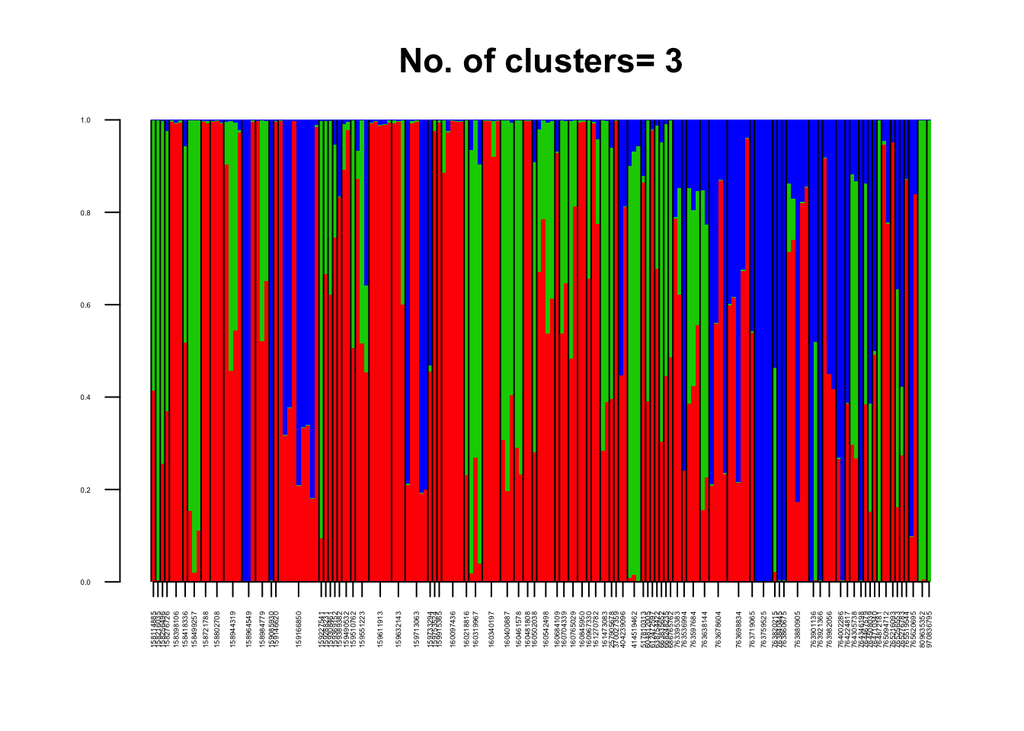

```
##
## Estimating on a 172 document collection.
## Fitting the 4 topic model.
## log posterior increase: 2629.1714, 876.8206, 210.7309, 93.7145, 39.8515, 25.4897, 18.1481, 6.9182, 8.5208, 7.9784, 9.9042, 3.2294, 4.837, 1.8063, 0.814, 0.5635, 0.3196, 0.2685, 1.36, 0.4299, 0.8352, 0.6768, 2.989, 0.8299, 0.2653, 0.1232, 0.0975, 0.0971, 0.1453, 0.0617, 0.0178, 0.0332, 0.0389, 0.0…
```

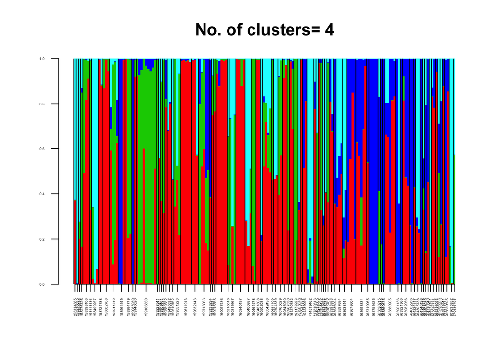

```
##        [,1]  [,2]  [,3]
##  [1,]   0.5   0.5   0.5
##  [2,]   1.5   1.5   1.5
##  [3,]   2.5   2.5   2.5
##  [4,]   3.5   3.5   3.5
##  [5,]   5.5   5.5   5.5
##  [6,]   7.5   7.5   7.5
##  [7,]   9.5   9.5   9.5
##  [8,]  12.0  12.0  12.0
##  [9,]  14.5  14.5  14.5
## [10,]  18.0  18.0  18.0
## [11,]  21.5  21.5  21.5
## [12,]  24.5  24.5  24.5
## [13,]  26.5  26.5  26.5
## [14,]  27.5  27.5  27.5
```

[output cut: 73 more lines]

### Left/Right hand level variation

Next we sort the columns as per the left hand/ right hand sample. We want to see if there is any distinctiveness among the clustering of the samples between the left and the right hands.

```r
sapply(2:4, function(k) structure_fossa_metagenome(fossa_data,left_right_label_fossa,k))
```

```
##
## Estimating on a 173 document collection.
## Fitting the 2 topic model.
## log posterior increase: 857.1337, 566.6017, 111.6675, 53.0788, 22.5107, 17.0358, 21.3569, 5.025, 1.2302, 0.6023, 0.3268, 0.3166, 0.1185, 0.0758, 0.1642, 0.1132, 0.0679, 0.0344, 0.0488, 0.0156, 0.0104, 0.0115, 0.0356, 0.1663, done.
```

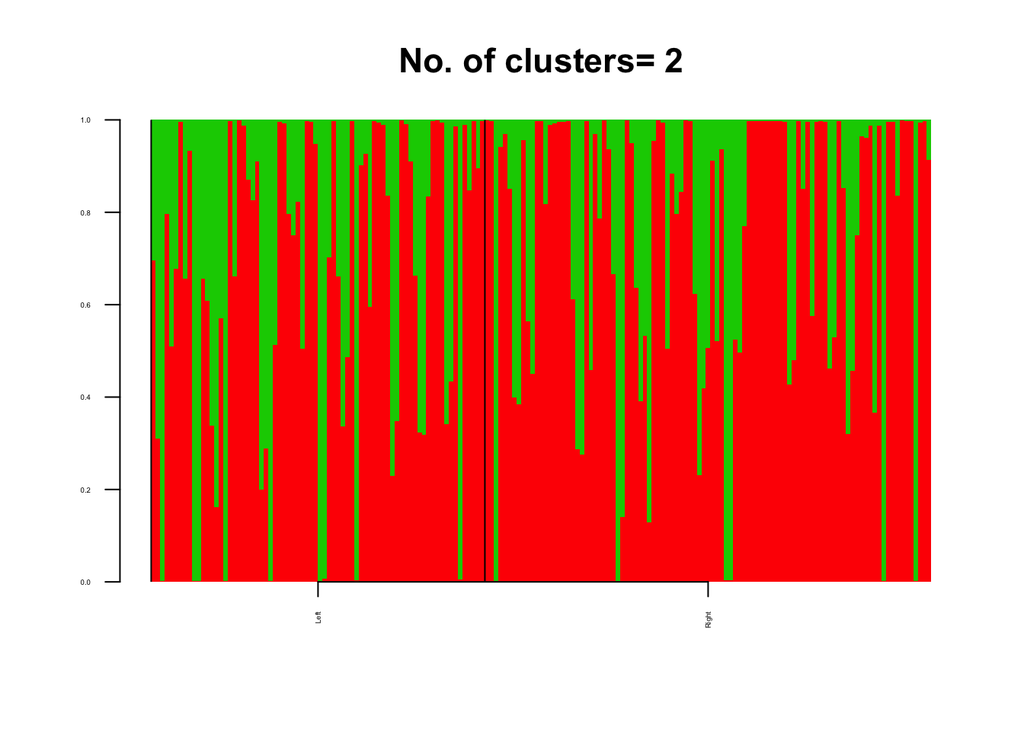

```
##
## Estimating on a 173 document collection.
## Fitting the 3 topic model.
## log posterior increase: 3177.9144, 481.324, 154.0299, 68.675, 32.7156, 55.8233, 38.2159, 10.1023, 13.7216, 2.7373, 3.1106, 0.4189, 0.3558, 0.1317, 0.1098, 0.0967, 0.0403, 0.0149, 0.0086, 0.0062, 0.0045, done.
```

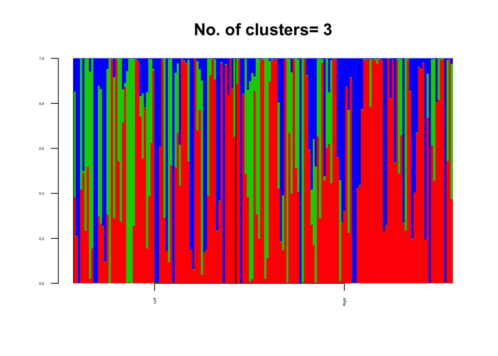

```
##
## Estimating on a 173 document collection.
## Fitting the 4 topic model.
## log posterior increase: 2650.8873, 882.4014, 218.5025, 90.3659, 47.7883, 20.1626, 19.6623, 22.9823, 8.3387, 7.2697, 11.059, 1.7094, 0.7515, 0.5366, 0.4057, 0.6265, 0.3028, 0.9299, 1.3493, 0.4205, 2.9149, 0.5397, 0.2532, 0.8748, 0.4399, 0.1369, 0.0945, 0.0751, 0.019, 0.0166, 0.0217, 0.0499, 0.0394…
```

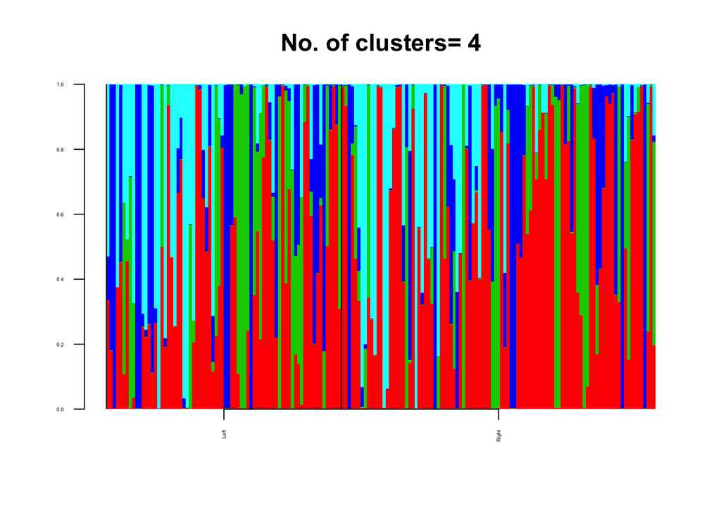

```
##       [,1]  [,2]  [,3]
## [1,]  37.0  37.0  37.0
## [2,] 123.5 123.5 123.5
```

## Crease Structure analysis

Now we first define two grouping vectors, one for signifying the left hand or right hand sample and the other signifying the individual.

First with respect to the left hand right hand combination.

```r
left_right_label_crease <- sapply(1:dim(metadata_crease)[1], function(x) strsplit(metadata_crease$HMPbodysubsite[x],"_")[[1]][1]);
```

Next with respect to the individual label.

```r
indiv_label_crease <- sapply(1:dim(metadata_crease)[1], function(x) strsplit(metadata_crease$Description[x],"_")[[1]][8]);
```

```r
structure_crease_metagenome <- function(counts_data,type_info,K)
{
  counts_data <- counts_data[which(!is.na(type_info)),];
  type_info <- type_info[which(!is.na(type_info))];
  Topic_Clus <- topics(counts_data,K,tol=0.0001);
  write.table(Topic_Clus$omega,paste0('../internal_data/hands_data/hands_topics_omega_',K,'.txt'));
  write.table(Topic_Clus$theta,paste0('../internal_data/hands_data/hands_topics_theta_',K,'.txt'));
  docweights <- as.matrix(read.table(paste0('../internal_data/hands_data/hands_topics_omega_',K,'.txt')));

  type_ordered <- type_info[order(type_info)];
  docweights_ordered <- docweights[order(type_info),];
  barplot(t(docweights_ordered),col=2:(K+1),axisnames=F,space=0,border=NA,main=paste("No. of clusters=",K),las=1,ylim=c(0,1),cex.axis=0.3,cex.main=1.4);
  labels = match(unique(type_ordered), type_ordered);
  abline(v=labels-1)

  labels_low=labels-1;
  labels_up=c(labels_low[2:length(labels_low)],dim(docweights_ordered)[1]);
  mid_point <- labels_low +0.5*(labels_up-labels_low);
  axis(1,at=mid_point, unique(type_ordered),las=2,cex.axis=0.3);
}
```

### Individual level variation

```r
sapply(2:4, function(k) structure_fossa_metagenome(crease_data,indiv_label_crease,k))
```

```
##
## Estimating on a 605 document collection.
## Fitting the 2 topic model.
## log posterior increase: 2853.8734, 364.231, 352.9474, 58.8808, 33.1939, 47.4817, 16.1986, 34.1022, 21.8277, 4.7419, 5.594, 4.8783, 3.8055, 0.989, 1.3855, 0.7994, 0.4348, 0.1188, 0.1934, 0.271, 0.1042, 0.0546, 0.0868, 0.0576, 0.0121, done.
```

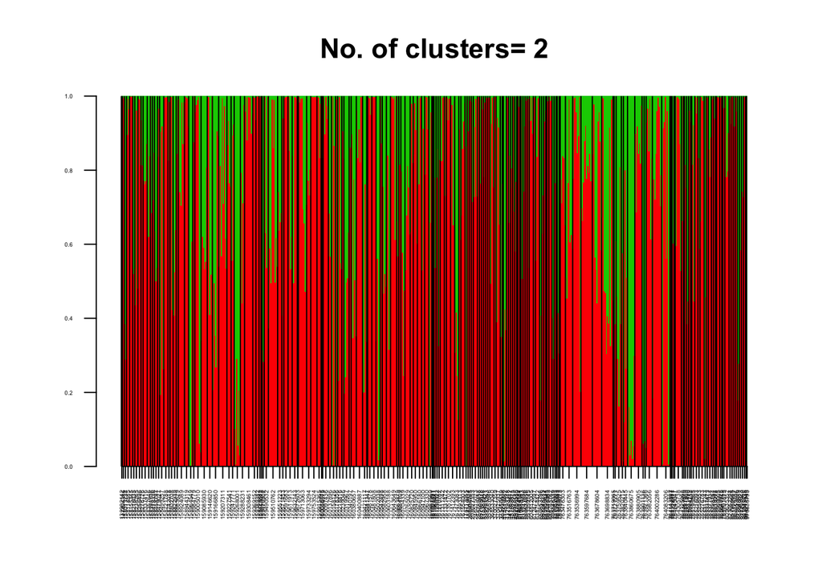

```
##
## Estimating on a 605 document collection.
## Fitting the 3 topic model.
## log posterior increase: 4473.4209, 875.4087, 164.7495, 71.7039, 67.6433, 68.1238, 94.2711, 219.6811, 144.0115, 139.2711, 87.75, 121.4727, 31.0262, 11.0188, 6.1844, 4.7087, 1.6459, 1.2191, 0.9556, 0.5766, 0.5042, 4.0482, 2.9732, 22.8199, 20.5811, 22.0843, 17.1494, 6.4711, 3.7909, 4.0045, 2.0126, 1…
```

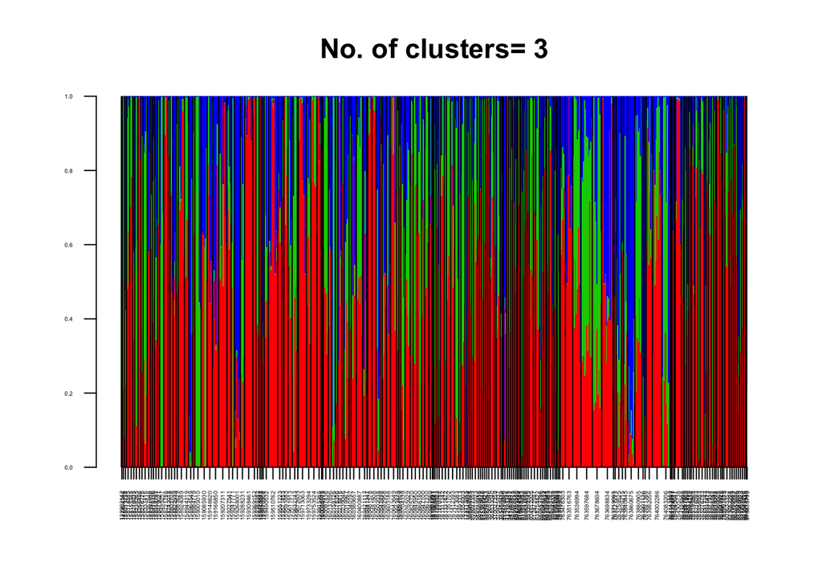

```
##
## Estimating on a 605 document collection.
## Fitting the 4 topic model.
## log posterior increase: 5442.3625, 1511.1662, 780.4594, 240.3639, 105.0958, 42.5952, 42.0545, 24.0454, 14.7522, 25.1701, 13.1108, 6.5443, 7.0022, 2.723, 0.7991, 0.6049, 0.9798, 0.5012, 0.2452, 0.2369, 0.4868, 0.0869, 0.0539, 0.0903, 0.0523, 0.0192, 0.0202, 0.0199, 0.028, 0.0612, 0.053, 0.1114, 0.…
```

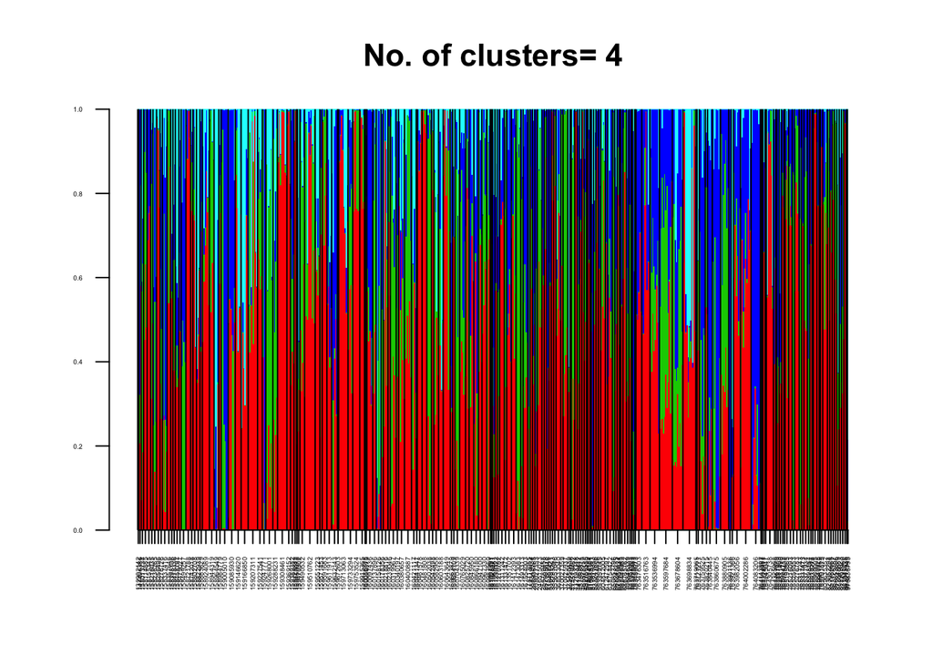

```
##         [,1]  [,2]  [,3]
##   [1,]   0.5   0.5   0.5
##   [2,]   2.0   2.0   2.0
##   [3,]   4.0   4.0   4.0
##   [4,]   6.5   6.5   6.5
##   [5,]   9.5   9.5   9.5
##   [6,]  12.0  12.0  12.0
##   [7,]  14.5  14.5  14.5
##   [8,]  17.5  17.5  17.5
##   [9,]  20.0  20.0  20.0
##  [10,]  23.0  23.0  23.0
##  [11,]  26.5  26.5  26.5
##  [12,]  29.0  29.0  29.0
##  [13,]  31.0  31.0  31.0
##  [14,]  33.5  33.5  33.5
```

[output cut: 178 more lines]

### Left/Right hand level variation

Next we sort the columns as per the left hand/ right hand sample. We want to see if there is any distinctiveness among the clustering of the samples between the left and the right hands.

```r
sapply(2:4, function(k) structure_fossa_metagenome(crease_data,left_right_label_crease,k))
```

```
##
## Estimating on a 627 document collection.
## Fitting the 2 topic model.
## log posterior increase: 3117.0336, 364.5363, 344.7917, 61.4938, 29.4116, 43.2348, 19.5715, 17.3117, 15.3672, 17.6618, 3.5301, 7.0734, 5.199, 2.6244, 1.1593, 1.4879, 0.6273, 0.7286, 0.156, 0.2336, 0.265, 0.18, 0.0972, 0.1042, 0.0614, 0.0161, done.
```

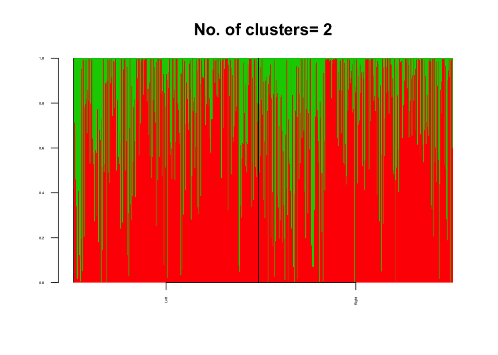

```
##
## Estimating on a 627 document collection.
## Fitting the 3 topic model.
## log posterior increase: 4755.7433, 897.1489, 200.9204, 102.6777, 81.2637, 90.3986, 123.3058, 125.4245, 104.9399, 64.61, 39.0981, 20.1337, 14.406, 15.5622, 8.0963, 4.478, 1.3939, 0.7819, 1.1238, 0.4549, 0.3993, 0.5792, 0.196, 0.1062, 0.0593, 0.0596, 0.101, 0.1692, 1.1905, 0.8876, 0.3768, 5.6993, 2…
```

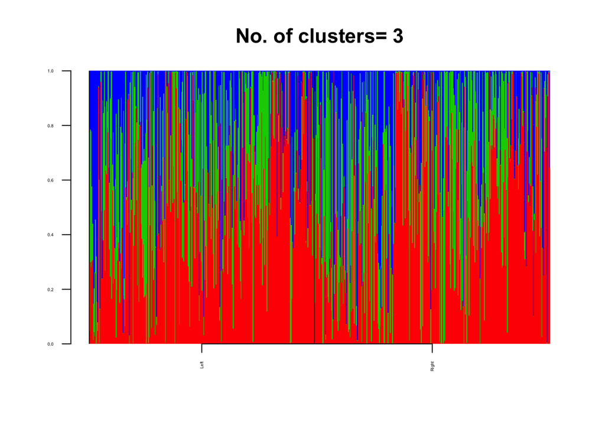

```
##
## Estimating on a 627 document collection.
## Fitting the 4 topic model.
## log posterior increase: 5449.7041, 1729.0878, 499.5763, 235.6618, 147.7005, 101.7511, 51.5136, 39.2268, 75.0311, 125.5359, 53.4393, 27.5441, 12.7812, 5.7743, 5.1995, 3.0497, 1.7119, 1.5139, 0.6251, 0.6301, 0.3929, 0.2739, 0.2183, 0.2067, 0.1411, 0.1278, 0.1379, 0.1619, 0.0878, 0.4205, 0.0893, 0.0…
```

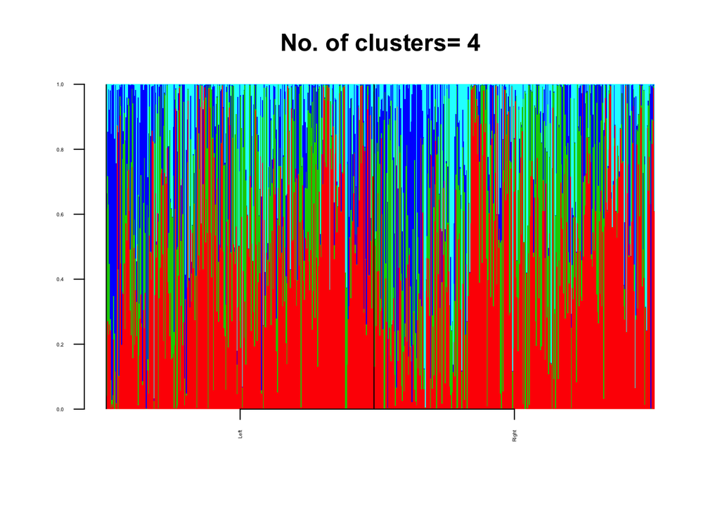

```
##       [,1]  [,2]  [,3]
## [1,] 153.0 153.0 153.0
## [2,] 466.5 466.5 466.5
```

## Understanding the variation due to L/R combination and individual variation

We save the p-values for the L/R combination and the individual variation. We compare the qvalues and lfdr across the genes for the fossa data

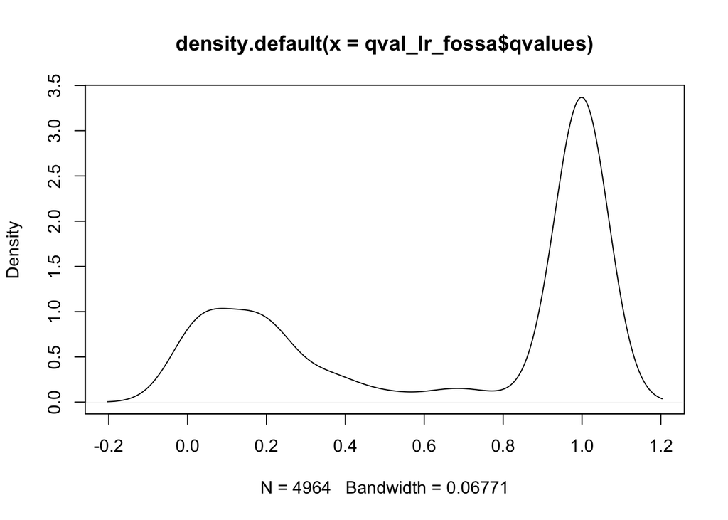

```r
pval_lr_fossa <- as.vector(read.table("../internal_data/hands_data/pval_lr_fossa.txt"));
pval_indiv_fossa <- as.vector(read.table("../internal_data/hands_data/pval_indiv_fossa.txt"));

qval_lr_fossa <- qvalue(p=as.numeric(as.matrix(pval_lr_fossa)));

plot(density(qval_lr_fossa$qvalues));
```

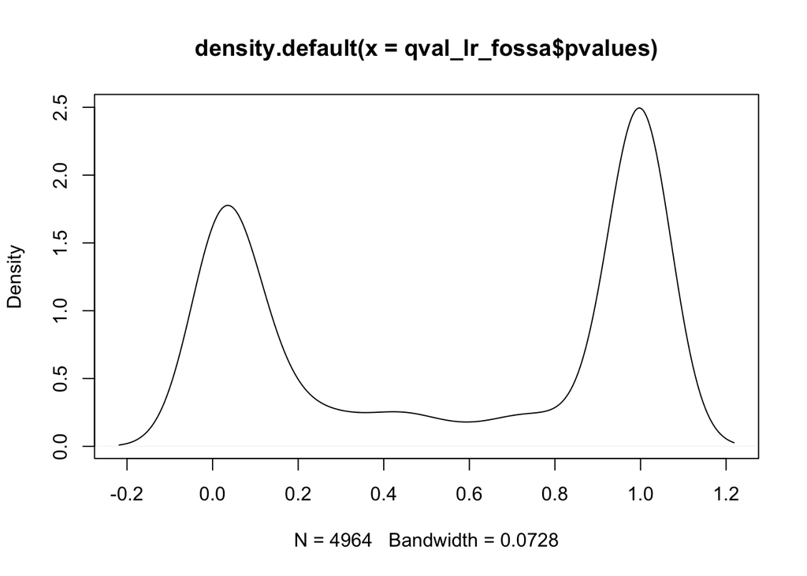

```r
plot(density(qval_lr_fossa$pvalues));
```

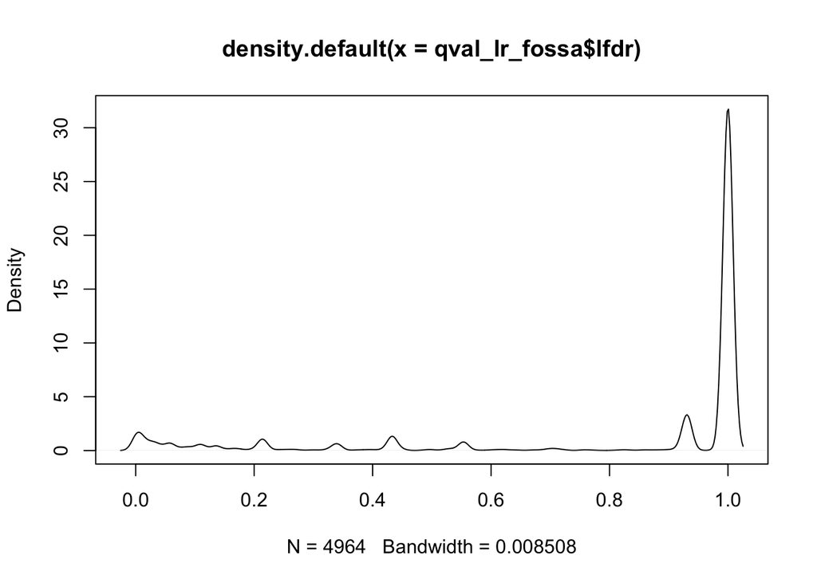

```r
plot(density(qval_lr_fossa$lfdr));
```

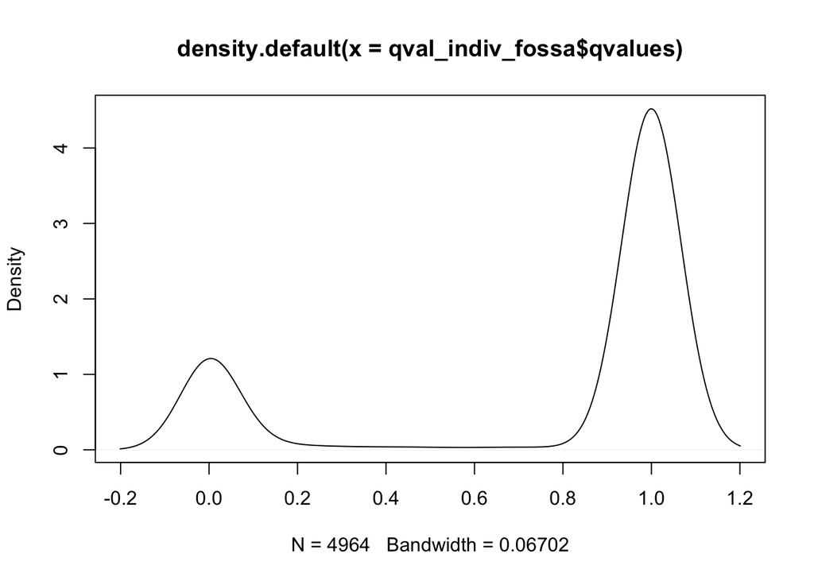

```r
qval_indiv_fossa <- qvalue(p=as.numeric(as.matrix(pval_indiv_fossa)));

plot(density(qval_indiv_fossa$qvalues));
```

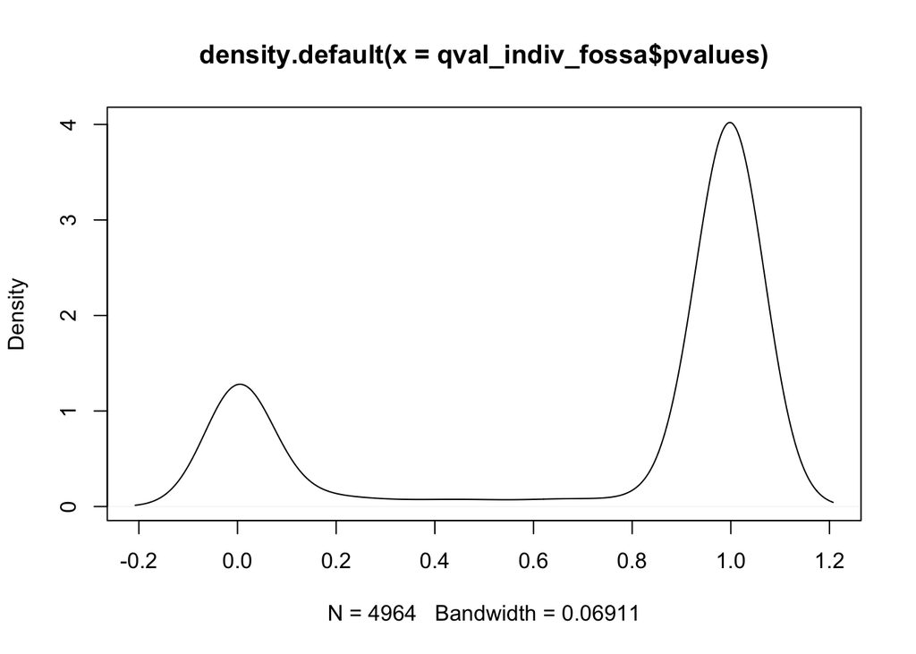

```r
plot(density(qval_indiv_fossa$pvalues));
```

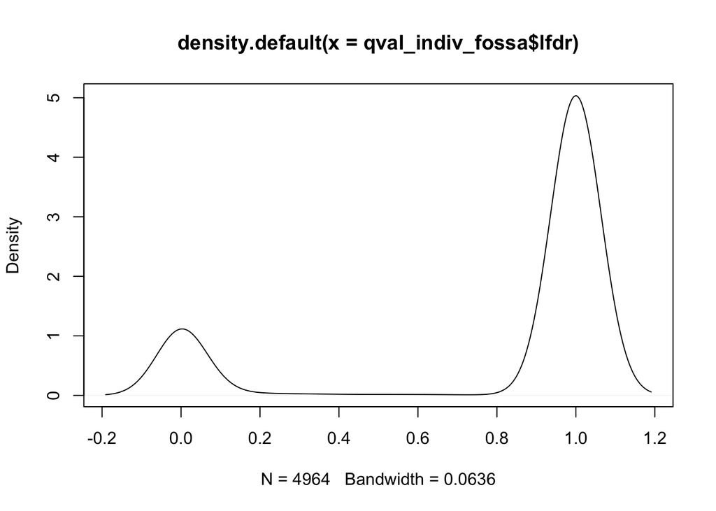

```r
plot(density(qval_indiv_fossa$lfdr));
```

Next, we carry out the same analysis for the crease data

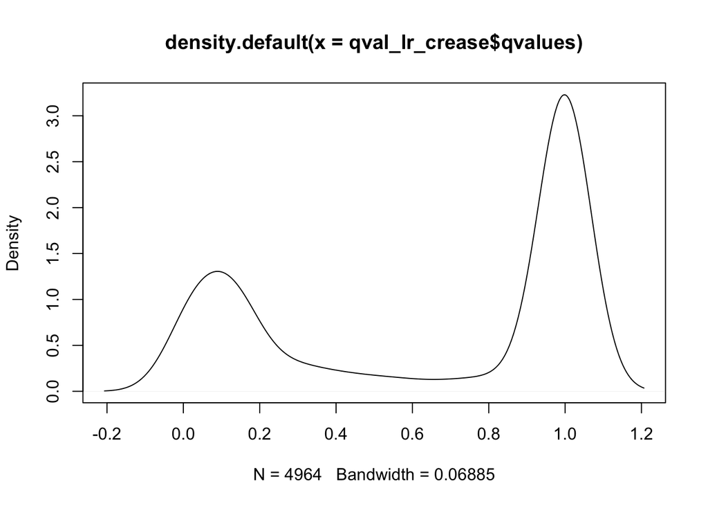

```r
pval_lr_crease <- as.vector(read.table("../internal_data/hands_data/pval_lr_crease.txt"));
pval_indiv_crease <- as.vector(read.table("../internal_data/hands_data/pval_indiv_crease.txt"));

qval_lr_crease <- qvalue(p=as.numeric(as.matrix(pval_lr_crease)));

plot(density(qval_lr_crease$qvalues));
```

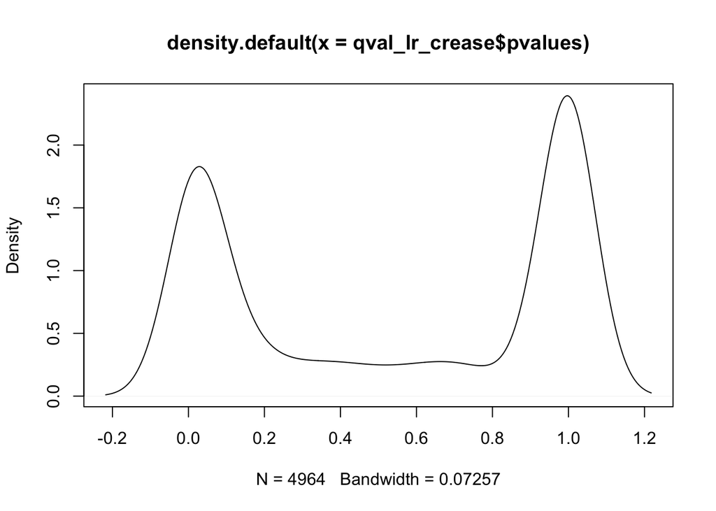

```r
plot(density(qval_lr_crease$pvalues));
```

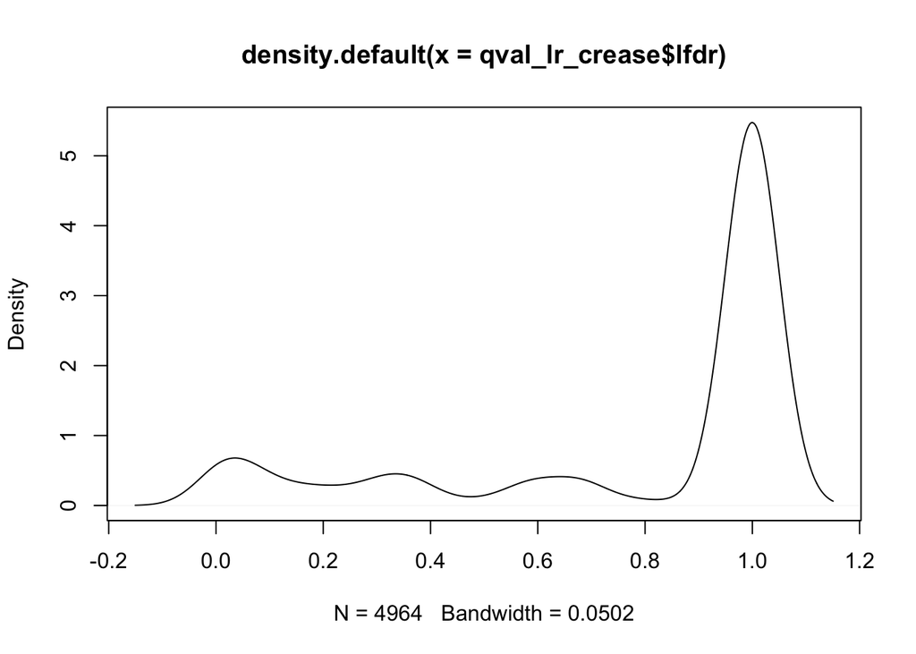

```r
plot(density(qval_lr_crease$lfdr));
```

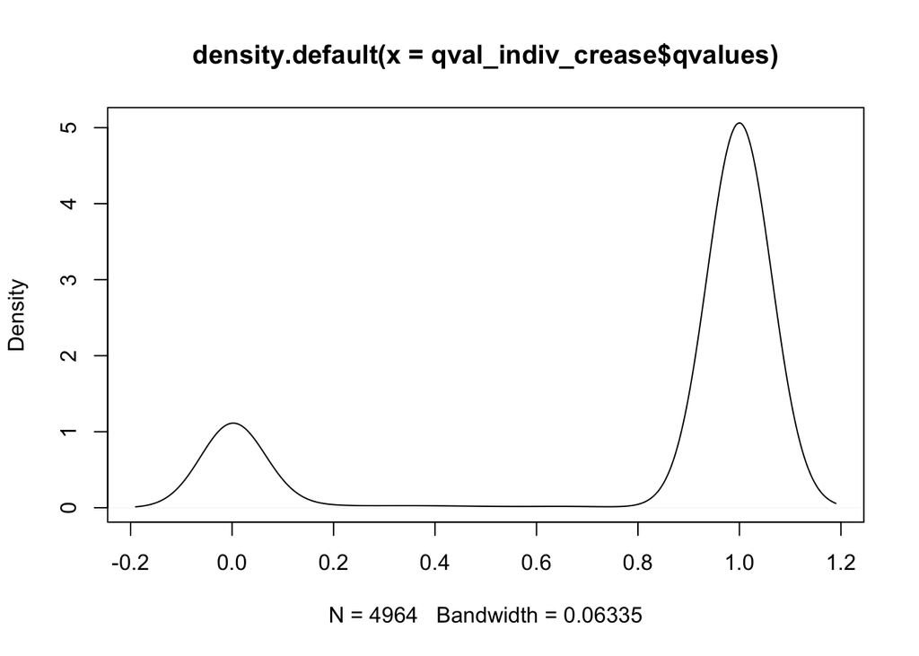

```r
qval_indiv_crease <- qvalue(p=as.numeric(as.matrix(pval_indiv_crease)));

plot(density(qval_indiv_crease$qvalues));
```

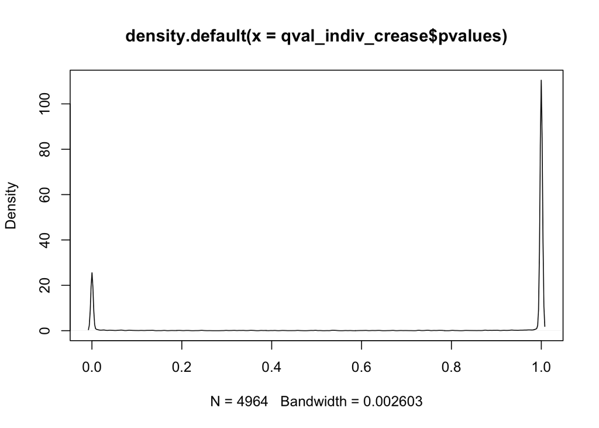

```r
plot(density(qval_indiv_crease$pvalues));
```

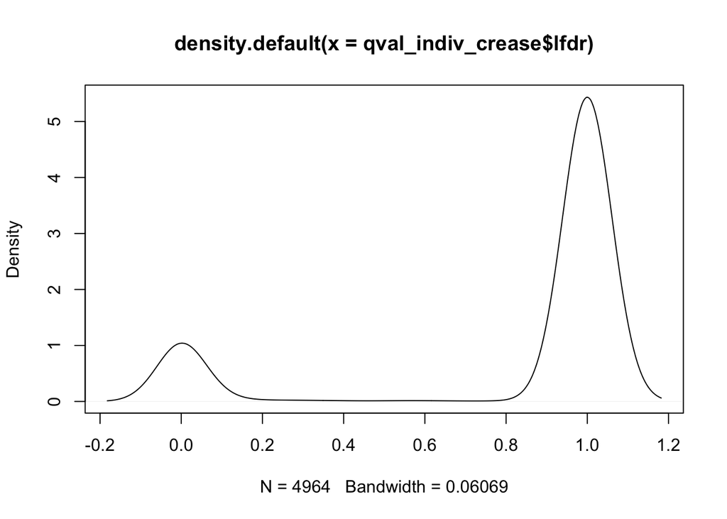

```r
plot(density(qval_indiv_crease$lfdr));
```

Finally we do a PCA plot on just the fossa data and the crease data to see if there is any L/R effect or individual variation effect that is observable. We first consider the PCs for the fossa data

## PC analysis fossa data

PC1 vs PC2 comparison for fossa data grouped by L/R combination.

```r
fossa_data <-fossa_data[which(!is.na(indiv_label_fossa)),];
indiv_label_fossa <- indiv_label_fossa[which(!is.na(indiv_label_fossa))];
left_right_label_fossa <- left_right_label_fossa[which(!is.na(indiv_label_fossa))]
pr <- prcomp(fossa_data %*% t(fossa_data));
suppressWarnings(suppressMessages(iplot(pr$x[,1], pr$x[,2], as.numeric(as.factor(left_right_label_fossa)),left_right_label_fossa)))
```

[interactive chart not shown]

PC2 vs PC3 comparison for fossa data grouped by L/R combination.

```r
suppressWarnings(suppressMessages(iplot(pr$x[,2], pr$x[,3], as.numeric(as.factor(left_right_label_fossa)),left_right_label_fossa)))
```

[interactive chart not shown]

PC1 vs PC2 comparison for fossa data grouped by individual.

```r
suppressWarnings(suppressMessages(iplot(pr$x[,1], pr$x[,2], as.numeric(as.factor(indiv_label_fossa)),indiv_label_fossa)))
```

[interactive chart not shown]

PC2 vs PC3 comparison for fossa data grouped by individual.

```r
suppressWarnings(suppressMessages(iplot(pr$x[,2], pr$x[,3], as.numeric(as.factor(indiv_label_fossa)),indiv_label_fossa)))
```

[interactive chart not shown]

## PC analysis crease data

PC1 vs PC2 comparison for crease data grouped by L/R combination.

```r
crease_data <-crease_data[which(!is.na(indiv_label_crease)),];
indiv_label_crease <- indiv_label_crease[which(!is.na(indiv_label_crease))];
left_right_label_crease <- left_right_label_crease[which(!is.na(indiv_label_crease))]
pr <- prcomp(crease_data %*% t(crease_data));
suppressWarnings(suppressMessages(iplot(pr$x[,1], pr$x[,2], as.numeric(as.factor(left_right_label_crease)),left_right_label_crease)))
```

[interactive chart not shown]

PC2 vs PC3 comparison for crease data grouped by L/R combination.

```r
suppressWarnings(suppressMessages(iplot(pr$x[,2], pr$x[,3], as.numeric(as.factor(left_right_label_crease)),left_right_label_crease)))
```

[interactive chart not shown]

PC1 vs PC2 comparison for crease data grouped by individual.

```r
suppressWarnings(suppressMessages(iplot(pr$x[,1], pr$x[,2], as.numeric(as.factor(indiv_label_crease)),indiv_label_crease)))
```

[interactive chart not shown]

PC2 vs PC3 comparison for crease data grouped by individual.

```r
suppressWarnings(suppressMessages(iplot(pr$x[,2], pr$x[,3], as.numeric(as.factor(indiv_label_crease)),indiv_label_crease)))
```

[interactive chart not shown]